# Most Damaging Weather Events

ncoutrakon

November 18, 2015

## Synopsis

The U.S. National Oceanic and Atmospheric Administration (USNOAA) has compiled a database of major storms and weather events. Part of this database includes injuries and fatalities caused by each storm, as well as an estimate property and crop damages as a result. In this analysis, we look to find out which types of event are the most harmful, economically and to the human population. We found that Tornados, Thunderstorm Winds, and Floods are the most damaging to our economy and population health. In addition, we draw attention to Tsunamis because although infrequent, they can have quite an impact on population health and our economy. We also provide a list of the most damaging events based on economic and population health, respectively.

## Data Processing

We start by downloading the raw data from the [USNOAA](https://d396qusza40orc.cloudfront.net/repdata%2Fdata%2FStormData.csv.bz2) website and storing it in our workspace.

```r
sturl <- "https://d396qusza40orc.cloudfront.net/repdata%2Fdata%2FStormData.csv.bz2"
stfile <- "stormdata.csv"

if(!file.exists(stfile)) {download.file(sturl, stfile, method = "curl"); stormdownloadDate<- date()}
if(!exists("stormdf")) stormdf <- read.csv(stfile, stringsAsFactors = F, na.strings = "")
```

Wow! That’s a lot of data. Notice that the 1million entries in this dataset represent data from across half a century. The easiest way to first dive into this data will be to slice it year by year. To do that, we create another column that specifically indicates the year each event was recorded. Once we do that, we can take a look at how many events were recorded each year to get an idea of the continuity of the recording process.

[figure not shown]

```r
library(ggplot2)
stormdf$posixtime <- strptime(stormdf[,2], "%m/%d/%Y %H:%M:%S")
stormdf$year <- as.numeric(format(stormdf$posixtime, "%Y"))

freqEVTYPE <- setNames(aggregate(stormdf$EVTYPE, list(stormdf$year),
                        function(x) length(table(x))), c("Year", "Types"))
qplot(Year, Types, data = freqEVTYPE, ylab = "Types of Events", main = "Event Types Reported")
```

```r
rstormdf <- stormdf[which(stormdf$year > 2007),]
```

When we analyze the damages on an economic and population basis, we will want to look at total damage per event but also want to keep in mind the frequency of each event. This will help us keep our findings in perspective and also analyize the average effect for each instance of an event. We create a dataframe to keep track of weather event totals below.

```r
nEVTYPES <- setNames(as.data.frame(table(rstormdf$EVTYPE), stringsAsFactors = F),
                c("Event", "Event Count"))
nEVTYPES <- nEVTYPES[order(nEVTYPES$'Event Count', decreasing = T),]
```

## Results

### Economic Damages

Now lets begin our analysis! We start with by looking at weather damages on Property and Crops. First, we create new variables that hold the multipliers for the numeric entries listed under the CROPDMG and PROPDMG columns. We then create a total damage column that multiplies and sums the damage for each event. With this column, we can tally the total damage caused by each event. We then merge this dataframe with the dataframe indicating the total number of occurences of each event. This will help us with our Averge Damage analysis.

```r
library(gridExtra)
multiplier <- c("0" = 1, K = 10^3, M = 10^6, B = 10^9)

rstormdf$cropmult <-multiplier[rstormdf$CROPDMGEXP]
rstormdf$propmult <-multiplier[rstormdf$PROPDMGEXP]
rstormdf$damage <- rstormdf$CROPDMG * rstormdf$cropmult + rstormdf$PROPDMG * rstormdf$propmult

#creates df for total economic damages by event
econdmg <- setNames(aggregate(rstormdf$damage, list(rstormdf$EVTYPE), sum), c("Event","Damage.USD"))
econdmg <- merge(econdmg, nEVTYPES)
econdmg$DMGper <- econdmg$Damage.USD / econdmg$'Event Count'
econdmg <- econdmg[order(econdmg$Damage.USD, decreasing = T),]
econdmg <- transform(econdmg, Event = reorder(Event, Damage.USD))
```

Take a look at the plots below.

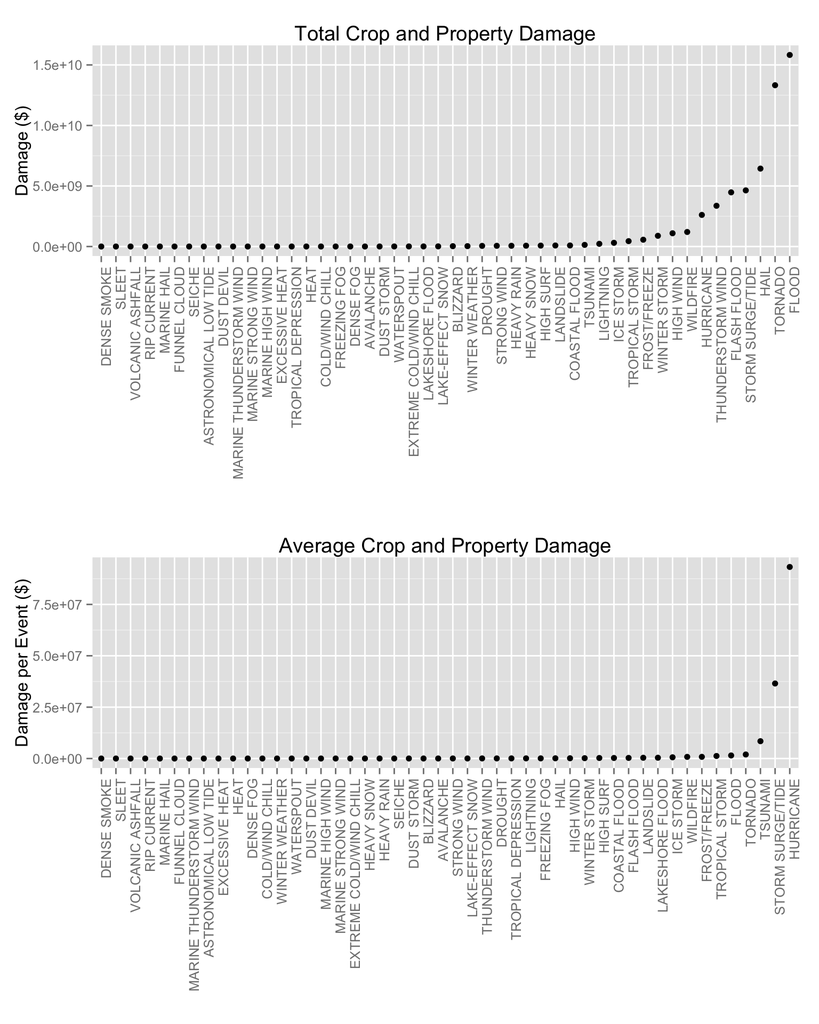

```r
eplot1 <- qplot(Event, Damage.USD, data = econdmg, xlab ="", ylab = "Damage ($)", main = "Total Crop and Property Damage")+
                theme(axis.text.x = element_text(angle = 90, hjust = 1))

eplot2 <- qplot(x = reorder(Event, DMGper), DMGper, data = econdmg, xlab ="", ylab = "Damage per Event ($)",
                main = "Average Crop and Property Damage")+
                theme(axis.text.x = element_text(angle = 90, hjust = 1))

grid.arrange(eplot1, eplot2, ncol = 1)
```

It looks like the significant events are the ones where the Total Damage is more than 2.5Billion dollars. Also take a look at Tsunamis and Storm Surge/Tide, in the Average Damage chart. Although infrequent, these events can be quite costly. We’ll want to note these events in our recommendatoin later.

```r
recondmg <- econdmg[which((econdmg$Damage.USD > 2.5*10^9)|(econdmg$Event %in% c("TSUNAMI", "STORM SURGE/TIDE"))),]
```

### Population Damages

```r
evfatal <- setNames(aggregate(rstormdf$FATALITIES, list(rstormdf$EVTYPE), sum), c("Event", "Fatalities"))
evinj <- setNames(aggregate(rstormdf$INJURIES, list(rstormdf$EVTYPE), sum), c("Event", "Injuries"))

popdmg <- merge(evfatal, evinj)
popdmg <- merge(popdmg, nEVTYPES)
popdmg$evDMG <- popdmg$Fatalities + .6*popdmg$Injuries
popdmg$evDMGper <- popdmg$evDMG / popdmg$'Event Count'*100
popdmg <- popdmg[order(popdmg$evDMG, decreasing = T),]
popdmg <- transform(popdmg, Event = reorder(Event, evDMG))
```

Immediately, when we look at the first few entries of our dataframe, sorted from most evDMG to least, we see that Tornados have an incredibly damaging total effect on human population. It dwarfs the rest of the top six entries combined. So for the next part of our analysis, we are going to temporarily remove Tornados so we can better analyize the other weather events. Don’t worry though, we’re going to add it back later!

```r
head(popdmg)
```

```
##                Event Fatalities Injuries Event.Count  evDMG   evDMGper
## 40           TORNADO        782     8949        6801 6151.4  90.448463
## 39 THUNDERSTORM WIND        114     1137       67665  796.2   1.176679
## 29         LIGHTNING        114      784        3155  584.4  18.522979
## 19              HEAT        160      672         545  563.2 103.339450
## 13       FLASH FLOOD        223      265       15408  382.0   2.479232
## 11    EXCESSIVE HEAT         97      344         447  303.4  67.874720
```

```r
outpopdmg <- popdmg[popdmg$Event != "TORNADO",]
```

Now, let’s plot our dataframes so we can see the total and average effect on population health.

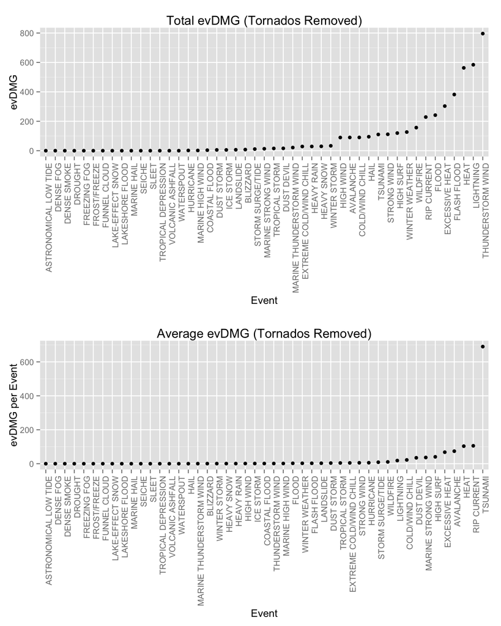

```r
library(gridExtra)
pplot1 <- qplot(Event, evDMG, data = outpopdmg, ylab = "evDMG",
                main = "Total evDMG (Tornados Removed)")+
                theme(axis.text.x = element_text(angle = 90, hjust = 1))
pplot2 <- qplot(x = reorder(Event, evDMGper), evDMGper, data = outpopdmg,
                ylab = "evDMG per Event", xlab = "Event",
                main = "Average evDMG (Tornados Removed)")+
                theme(axis.text.x = element_text(angle = 90, hjust = 1))

grid.arrange(pplot1, pplot2, ncol = 1)
```

Again, note that Tsunamis and Avalanches have been underestimated on a per event basis for population health. We’ll include them in our final recommendation. Based on this, its seems like 200 in evDMG is a good cutoff point to imply significance. Let’s remove everything else and use only those points as part of our recommendation, including Tornados of course.

```r
rpopdmg <- popdmg[which((popdmg$evDMG > 200)| (popdmg$Event %in% c('TSUNAMI', "AVALANCHE"))),]
```

### Recommendations

```r
#worst for the economy
recondmg
```

```
##                Event  Damage.USD Event.Count      DMGper
## 14             FLOOD 15824587300       10646  1486435.03
## 40           TORNADO 13324261090        6801  1959162.05
## 18              HAIL  6436795350       59542   108105.12
## 37  STORM SURGE/TIDE  4637493000         127 36515692.91
## 13       FLASH FLOOD  4475061230       15408   290437.51
## 39 THUNDERSTORM WIND  3365070240       67665    49731.33
## 24         HURRICANE  2610410000          28 93228928.57
## 43           TSUNAMI   134879000          16  8429937.50
```

```r
#worst for the population
rpopdmg
```

```
##                Event Fatalities Injuries Event.Count  evDMG   evDMGper
## 40           TORNADO        782     8949        6801 6151.4  90.448463
## 39 THUNDERSTORM WIND        114     1137       67665  796.2   1.176679
## 29         LIGHTNING        114      784        3155  584.4  18.522979
## 19              HEAT        160      672         545  563.2 103.339450
## 13       FLASH FLOOD        223      265       15408  382.0   2.479232
## 11    EXCESSIVE HEAT         97      344         447  303.4  67.874720
## 14             FLOOD        144      163       10646  241.8   2.271276
## 34       RIP CURRENT        161      113         217  228.8 105.437788
## 43           TSUNAMI         33      129          16  110.4 690.000000
## 2          AVALANCHE         63       45         122   90.0  73.770492
```

But we draw special attention to the types of weather events which have shown to have significant impacts on both population and the economy. It is with this that we give our final recommendation to mitigate the effects of Floods, Thunderstorms, Tornados, and Tsunamis.

```r
#worst for the economy AND the population
combodf <- merge(rpopdmg,recondmg)
combodf[,c(1,2, 3, 6, 7)]
```

```
##               Event Event.Count Fatalities   evDMGper  Damage.USD
## 1       FLASH FLOOD       15408        223   2.479232  4475061230
## 2             FLOOD       10646        144   2.271276 15824587300
## 3 THUNDERSTORM WIND       67665        114   1.176679  3365070240
## 4           TORNADO        6801        782  90.448463 13324261090
## 5           TSUNAMI          16         33 690.000000   134879000
```